# Analisis Akun Instagram COS Indonesia (@citizen_os_indonesia)

# Insight:

Berdasarkan scatterplot hubungan antara panjang caption dan engagement (likes + komentar), terlihat bahwa sebagian besar posting akun COS Indonesia memiliki engagement di bawah 150 interaksi, dengan kecenderungan positif lemah antara panjang caption dan engagement. Garis trendline menunjukkan sedikit kenaikan seiring bertambahnya jumlah karakter pada caption, yang berarti posting dengan caption lebih panjang cenderung memperoleh engagement sedikit lebih tinggi, meskipun perbedaannya tidak signifikan. Sebagian besar titik data tersebar secara acak, menandakan bahwa faktor lain—seperti isi pesan, visual, atau waktu posting—kemungkinan memiliki pengaruh yang lebih kuat terhadap performa posting dibanding sekadar panjang teks caption. Dengan kata lain, audiens akun ini tampaknya lebih merespons kualitas dan relevansi isi caption ketimbang seberapa panjang caption tersebut.

```python
# Analisis Hastag
# Tujuan: “Hashtag mana yang paling sering digunakan, dan apakah ada hubungannya dengan engagement tinggi?”
# Ekstrak hastag dari scarping
import re
from collections import Counter

# Pastikan kolom caption tidak kosong
df_posts['caption'] = df_posts['caption'].fillna('')

# Ekstrak hashtag dari caption
all_hashtags = []
for cap in df_posts['caption']:
    tags = re.findall(r'#\w+', cap)
    all_hashtags.extend([t.lower() for t in tags])

# Hitung frekuensi
hashtag_counts = Counter(all_hashtags)
top10_hashtags = pd.DataFrame(hashtag_counts.most_common(10), columns=['Hashtag', 'Frekuensi'])

top10_hashtags
```

|  | Hashtag | Frekuensi |
| --- | --- | --- |
| 0 | #iof2024 | 75 |
| 1 | #citizenosindonesia | 47 |
| 2 | #citizenos | 44 |
| 3 | #indonesiaopinionfestival | 41 |
| 4 | #dprmendengar | 32 |
| 5 | #civictech | 27 |
| 6 | #dprri | 27 |
| 7 | #democracy | 22 |
| 8 | #indonesianopinionfestival | 20 |
| 9 | #digitaldemocracy | 16 |

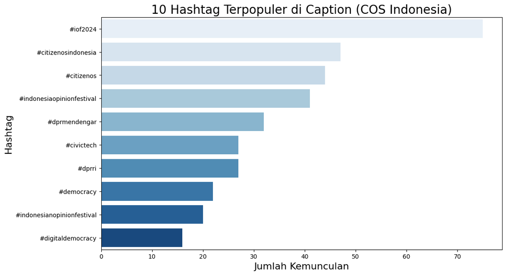

```python
# Visualisasikan
#import matplotlib.pyplot as plt
import seaborn as sns

plt.figure(figsize=(12,7))
sns.barplot(data=top10_hashtags, x='Frekuensi', y='Hashtag', palette='Blues')
plt.title('10 Hashtag Terpopuler di Caption (COS Indonesia)',fontsize=20)
plt.xlabel('Jumlah Kemunculan',fontsize=16)
plt.ylabel('Hashtag',fontsize=16)
plt.grid(False)
plt.show()
```

```python
# Analisis workloud kolom komentar
# Tujuan: “Apa yang paling sering dibicarakan atau dirasakan audiens di kolom komentar?”
# Langkah 1- persiapan data komentar
from pandas import json_normalize
import json

# Baca file JSON
with open('dataset_instagram-scraper_2025-10-13_07-54-13-662.json', 'r', encoding='utf-8') as f:
    data = json.load(f)

# Normalisasi kolom komentar
df_comments = json_normalize(
    data,
    record_path=['latestComments'],
    meta=[['id']],       # ambil id postingan
    sep='_',
    meta_prefix='post_'  # tambahkan prefix biar beda
)

df_comments.head()

# Abaikan metadata
df_comments = json_normalize(data, record_path=['latestComments'], sep='_')

#hasil
df_comments['text'].head()
```

```
0    Untuk jadi new volunteer bisa ka?semoga ada ke...
1                            Asikkk gk sabar banget 😍🔥
2                          acaranya tanggal berapa ka?
3    Halo kak @nurulll.jua , nantikan kesempatan vo...
4                         @demediciemira see you soon🔥
Name: text, dtype: object
```

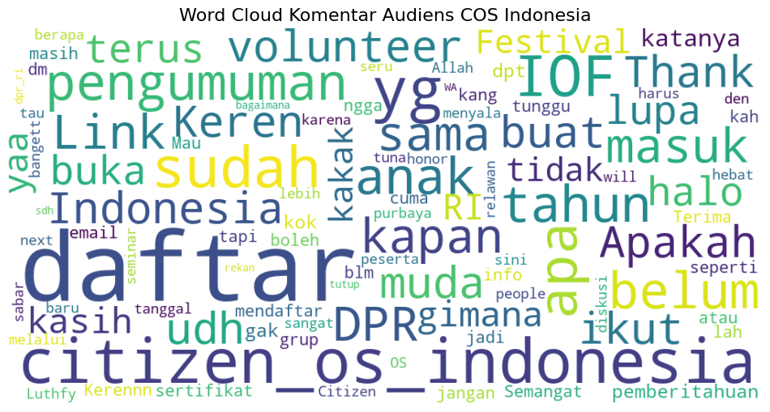

```python
# Langkah 1 — Buat Word Cloud dari Komentar
from wordcloud import WordCloud, STOPWORDS
import matplotlib.pyplot as plt

# Gabungkan semua komentar jadi satu teks besar
all_comments = ' '.join(df_comments['text'].dropna().astype(str))

# Tambahkan daftar stopwords (kata umum yang mau dihapus)
stopwords = set(STOPWORDS)
stopwords.update([
    'ya', 'yang', 'dan', 'di', 'ke', 'ini', 'itu',
    'kak', 'ka', 'iya', 'aku', 'kamu', 'kami', 'kita',
    'mereka', 'gk', 'ga', 'aja', 'dong', 'nih', 'semoga',
    'banget', 'asik', 'asikkk', 'ada', 'nya', 'saya', 'min', 'bisa',
    'juga', 'udah', 'untuk', 'dari', 'lagi', 'dalam'
])

# Buat word cloud
wc = WordCloud(
    width=1000,
    height=500,
    background_color='white',
    stopwords=stopwords,
    collocations=False,
    max_words=100
).generate(all_comments)

# Tampilkan hasil
plt.figure(figsize=(12,7))
plt.imshow(wc, interpolation='bilinear')
plt.axis('off')
plt.title('Word Cloud Komentar Audiens COS Indonesia', fontsize=16)
plt.show()
```

# Insight:

- Berdasarkan hasil word cloud kolom komentar, terlihat bahwa kata-kata yang paling sering muncul di antara audiens akun COS Indonesia meliputi “volunteer”, “daftar”, “IOF”, “Citizen_os_Indonesia”,“DPR”, dan pengumuman. Dominasi kata-kata ini menunjukkan bahwa audiens memiliki antusiasme tinggi terhadap kegiatan yang diselenggarakan serta menunjukkan keinginan untuk berpartisipasi sebagai relawan atau peserta acara. Pola ini juga mengindikasikan adanya komunitas aktif yang terlibat secara emosional dengan inisiatif COS Indonesia, khususnya pada kegiatan berbasis kolaborasi dan aksi sosial.
- Namun sangat disyangkan bahwa visi & misi program IOF sebagai platform demokrasi ataupu ruang aspirasi tidak tersampaikan di benak masyarakat.
- Selain itu, munculnya kata seperti “belum”, “kapan”, dan “info” juga menyoroti adanya gap komunikasi — audiens tampak aktif mencari kejelasan tentang mekanisme pendaftaran, jadwal, atau tindak lanjut dari kegiatan yang diunggah.
- Audiens COS Indonesia sangat aktif dan tertarik untuk terlibat, tetapi masih membutuhkan sistem komunikasi yang lebih responsif dan terstruktur agar antusiasme tersebut bisa diubah menjadi partisipasi nyata.

# Rekomendasi:

a. Perkuat sistem informasi & auto-response digital. Buat highlight Instagram khusus seperti “FAQ Pendaftaran”, “Timeline Kegiatan”, atau gunakan chatbot/auto-reply untuk menjawab pertanyaan umum (“Kapan buka?”, “Daftar di mana?”).

b. Gunakan konten informatif terjadwal. Setiap pengumuman besar seperti volunteer call atau event bisa dilengkapi dengan infografis jadwal, link, dan FAQ agar audiens tidak perlu mencari ulang di kolom komentar.

c. Optimalkan community management. Libatkan relawan komunikasi atau tim social media tambahan saat event besar agar interaksi di komentar dapat dikelola lebih cepat dan konsisten.

d. Bangun kredibilitas IOF sebagai brand demokrasi digital. Gunakan storytelling konten, testimoni peserta, dan behind the scene event untuk memperkuat asosiasi publik bahwa IOF bukan hanya “kegiatan tahunan”, tetapi platform aspirasi yang hidup dan berdampak.

# Kesimpulan

Word cloud komentar menunjukkan antusiasme tinggi audiens terhadap kegiatan COS Indonesia, terutama pada aspek partisipasi dan keterlibatan relawan. Namun, banyaknya pertanyaan berulang seperti “kapan”, “belum”, dan “daftar” menandakan perlunya peningkatan manajemen komunikasi digital agar informasi lebih mudah diakses dan workload admin tidak terlalu berat. Dengan strategi komunikasi yang lebih sistematis dan responsif, COS Indonesia dapat mengonversi minat tinggi audiens menjadi partisipasi aktif yang lebih luas, sekaligus memperkuat posisi IOF sebagai ruang aspirasi publik yang inklusif dan berkelanjutan. 🌿

# Berikut kesimpulan komprehensif untuk peningkatan sosial media Instagram COS Indonesia (@citizen_os_indonesia) berdasarkan hasil analisis dalam dokumen:

📌 Implikasi: perlu penyesuaian timing publikasi berdasarkan data engagement, serta diversifikasi konten agar pesan organisasi tetap hidup di luar momen rekrutmen.

3. Persepsi dan Keterhubungan Pesan
   - Word cloud komentar menyoroti kata seperti “volunteer”, “daftar”, “IOF”, “DPR”, dan “info” — menandakan minat tinggi terhadap partisipasi publik.
   - Namun, pesan substantif COS Indonesia tentang demokrasi dan civic engagement belum sepenuhnya tersampaikan secara emosional.
   - Audiens lebih tertarik pada figur, kolaborasi besar, dan ajakan konkret dibanding pesan idealistik.

📌 Implikasi: pesan organisasi perlu dikemas lebih humanistik melalui storytelling, testimoni, atau profil relawan agar nilai demokrasi terasa dekat dan relevan.

4. Efektivitas Komunikasi & Manajemen Komunitas
   - Munculnya banyak komentar seperti “kapan”, “belum”, dan “info” menunjukkan adanya celah komunikasi dan kebutuhan auto-response system.
   - Beban admin tinggi saat event besar mengindikasikan perlunya struktur community management yang lebih responsif.

📌 Rekomendasi teknis: - Tambahkan Instagram Highlight “FAQ”, “Timeline Kegiatan”, dan “Cara Daftar”. - Gunakan auto-reply atau chatbot untuk menjawab pertanyaan umum. - Libatkan relawan komunikasi saat kampanye besar untuk mempercepat respons.

# Kesimpulan Umum

Akun Instagram COS Indonesia menunjukkan potensi engagement yang kuat namun belum dimaksimalkan secara strategis. Dengan membangun ritme konten yang konsisten, memperkuat storytelling berbasis pengalaman, serta menerapkan sistem komunikasi yang responsif, COS Indonesia dapat:

- Mengubah antusiasme tinggi audiens menjadi partisipasi nyata,
- Memperkuat citra IOF sebagai ruang aspirasi publik yang inklusif dan berkelanjutan,
- Dan menjaga keberlanjutan pesan demokrasi digital sepanjang tahun.